# Generalized Additive Models (GAMs)

2022-09-27

# **The Set-up**

## *Learning objectives.*

1. Implement as simple/multiple Generalized Additive Model in `R`.
2. Understand the difference between smoothed and linear terms in a Generalized Additive Model.
3. Determine the fit of a Generalized Additive Models and establish how good a model is.
4. Reduce a Generalized Additive Models to the minimum adequate number of predictors using a step-wise procedure.

## *Before you start*

The practical will be run using *RStudio cloud* to avoid individual machine troubleshooting. This means you **need** to have an account for *RStudio cloud*.

However, remember to have [`R`](https://cran.r-project.org) and [R-studio](http://www.rstudio.com/) in your/room computer so you can work on the project after class.

**You should have also** 1. Read chapter 18 of Crawley the R book. 2. Done the Tutorial for this week.

## *The way it’s going to be run*

In this 3h practical you will to implement what you have learned in the class about Regression Analyses in `R`.

You will be building and **R-Markdown** document during the class. **R-Markdown** documents allows you to combine your code, its results, and your prose commentary into a single document. If you manage to produce a document your code works. The resulting file (a html) is what you will hand-in at the end of the practical.

The final document will have three classes of boxes

The text in the blue filled box marked as **Your task** states what you need to do

```r
#
# The code in the window marked like this shows where you need to write your code
#
```

The text in the green filled box marked as **Question** phrases a question, and where you will place the answer to the **question** is marked as ***PLACE YOUR ANSWER HERE**.

## About the data you will use.

The data to be used in this week practical is a combination of the biodiversity data from the [Biowide](https://ecos.au.dk/forskningraadgivning/temasider/biowide) project, which aimed at collecting biodiversity data from 130 terrestrial sampling sites across Denmark. The data-set contains data for Plants (vascular plants and bryophytes), fungi (lichens and macrofungi), gastropods, and arthropods. You can get the [biodiversity data](https://www.gbif.org/dataset/cd4eb3ec-0a18-42b4-bda4-155716ddd7b1#description) from the Danish Biodiversity Information Facility. For further information on the project check the publication.

Although environmental variables were collected as part of Biowide, this data is not available for our use. The data on environmental variables included in the table you will use comes from multiple Geospatial data-sets I complied for this course.

Here you will focus on the flowing variables:

**1) decimalLongitude**: East-West position in decimal-degrees of a sample site coming from [Biowide](https://ecos.au.dk/forskningraadgivning/temasider/biowide).

**2) decimalLatitude**: North-South position in decimal-degrees of a sample site coming from [Biowide](https://ecos.au.dk/forskningraadgivning/temasider/biowide).

**3) S.AllGrp**: The total species richness of a sample site (sum of the unique species of all sampled groups in a site) coming from [Biowide](https://ecos.au.dk/forskningraadgivning/temasider/biowide).

**4) landsdele**: Regional political unit of Denmark coming form the Database of Global Administrative Areas [GADAM](https://gadm.org).

**5) Geology**: Geological formation coming from the [Denamrk’s geological service](https://eng.geus.dk/products-services-facilities/data-and-maps/maps-of-denmark).

**6) logitNatDensBasMp**: logit transformed Density of natural land cover types as defined by [BASEMAP](https://envs.au.dk/en/research-areas/society-environment-and-resources/land-use-and-gis/basemap).

**7) log10Dis2Cost**: log10 transformed Distance in km of a sampled site to the coast estimated by me using Denmark high resolution contour map coming form the Database of Global Administrative Areas [GADAM](https://gadm.org).

**8) HII**: [Human Influence Index](https://sedac.ciesin.columbia.edu/data/set/wildareas-v2-human-influence-index-geographic), a measurement of the anthropogenic impacts on the environment.

**9) log10Slope30mAgg**: log10 of the maximum rate of change in value from that cell to its neighbours estimated based on the [SRTM-30m DEM](https://www2.jpl.nasa.gov/srtm/).

**10) PrecSea**: Seasonality of precipitation measured as the variability of monthly values (using the CV) coming the [CHELSA-climatologies](https://chelsa-climate.org) .

## 1) The first step: Loading the data

**Your task:**

Load the data in *Biowide_AllSppRich.csv*, located in the files of the project

Use `read.csv` to load the file - The file is comma-separated

Save the object as an object named `DK.Biodiv`.

```r
# Read the file and save it as an object named `DK.Biodiv`
DK.Biodiv <-  read.csv("Data/Biowide_AllSppRich.csv")
# Use the function head to print the five first rows
head(DK.Biodiv)
```

```
##   X ID decimalLongitude decimalLatitude S.AllGrp   landsdele
## 1 1  1         10.05716        57.59033      302 Nordjylland
## 2 2  3         10.08032        57.58100      227 Nordjylland
## 3 3  4         10.21615        56.93747      296 Nordjylland
## 4 4  5         10.22988        56.93213      337 Nordjylland
## 5 5  6         10.24092        57.59655      195 Nordjylland
## 6 6  7         10.24669        55.12991      366  Syddanmark
##                Geology   HII PrecSea logitNatDensBasMp log10Dis2Cost
## 1 Marine sand and clay 21.19   24.00         2.8438517      2.654885
## 2         Aeolian sand 24.67   24.08         1.5813809      3.034781
## 3 Marine sand and clay 19.21   21.00         0.6789307      3.537708
## 4         Beach ridges 21.06   20.93         3.9935775      3.380351
## 5         Aeolian sand 26.72   25.00         3.1599758      3.097744
## 6        Glaciofluvial 31.91   19.27         0.4351384      3.583936
##   log10Slope30mAgg
## 1        0.4440448
## 2        0.4207806
## 3        0.2314696
## 4        0.3211840
## 5        0.3671695
## 6        0.7732011
```

## 2) How does my response variable change as a function of each predictor?

**Your task:**

Graphically explore how `S.AllGrp` changes as a function of either `logitNatDensBasMp`, `log10Dis2Cost`, `HII`, `log10Slope30mAgg`, `PrecSea`. For this, you will:

- Plot a scatter plots for each `S.AllGrp ~` *predictor* combination.
- Build a Generalized linear model using the function `?glm()`. Remember to use the right `family` given the response variable type.
- Plot a line representing the linear association between `S.AllGrp` **AND** *predictor*.
- Build a Generalized Additive Model (GAM) for each `S.AllGrp ~` *predictor* combination using the function `gam()`. Remember to use the right `family` given the response variable type.
- Plot a line representing the smoothed association between `S.AllGrp` **AND** *predictor*.

**YOU WILL USE a `for()` loop to make this figure**.

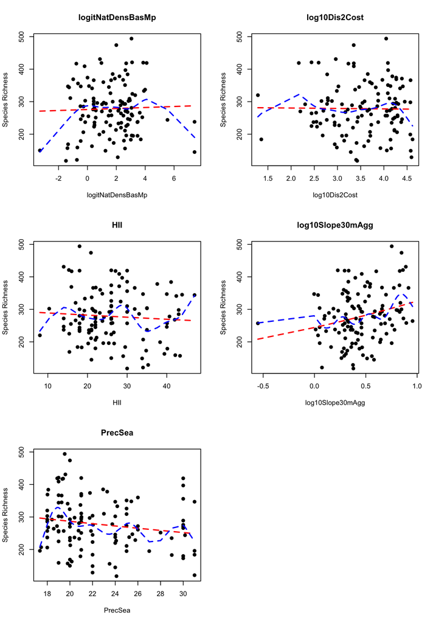

```r
# Start by setting a plotting space with three (3) rows and two (2) columns, making sure that plots are added row-wise
par(mfrow = c(3, 2)) # add a vector with the number of rows and number of columns in the plotting space

# start a for() Loop
for (Var in c("logitNatDensBasMp", "log10Dis2Cost", "HII", "log10Slope30mAgg", "PrecSea")){
# Scatter plot of S.AllGrp vs the evaluated predictor using the test.
 plot(x = DK.Biodiv[,Var], # The values for the predictor
      y = DK.Biodiv[,"S.AllGrp"], # The values for the response,
      pch = 19, # make the points filled circles
      main = Var,  # Add a title to the figure
      ylab = "Species Richness", # Y-axis name
      xlab = Var # X-axis name
      )

 # Build a linear regression object created with the glm() function.
  Reg.Tmp <- glm(formula(paste0("S.AllGrp ~",Var)),
                 data = DK.Biodiv,
                 family = "poisson")

# Add a trend line using the predict() function on the glm model created above
  lines(x=sort(DK.Biodiv[,Var]), # the ordered predictor
        y=predict(Reg.Tmp,type="response")[order(DK.Biodiv[,Var])], # the predictions ordered by the predictor
        col="red", # the colour of the line
        lwd = 2,  # the width of the line
        lty = 2) # the type of the line

# Build a generalized additive model regression object created with the gam() function.
  GAM.Tmp <- gam(formula(paste0("S.AllGrp ~ s(",Var,",k=10)")),
                 data = DK.Biodiv,
                 family = "poisson")
# Add a trend line using the predict() function on the gam model created above
  lines(x=sort(DK.Biodiv[,Var]),
        y=predict(GAM.Tmp,type="response")[order(DK.Biodiv[,Var])],
        col="blue",
        lwd = 2,  # the width of the line
        lty = 2) # the type of the line
  }
```

**Question:** Based on these graphical representations, what do you see?

For the GLM, It appears that there is a weak relation between `S.AllGrp` and most predictors. The GAM, generates a model with a wiggleness that match the response variable

**Your task:** Create a table where you compare the deviance explained by by each predictor based on your GLM and GAM models.

**YOU WILL USE a `sapply()` loop to make this table**.

```r
# table comparing the deviance explained by by each predictor based on your GLM and GAM
# Save the table as an object named DevTable
DevTable <- sapply(c("logitNatDensBasMp", "log10Dis2Cost", "HII", "log10Slope30mAgg", "PrecSea"),
       function(Var){

# Build a linear regression object created with the glm() function.
  GLMM.Tmp <- glm(formula(paste0("S.AllGrp ~",Var)),
                 data = DK.Biodiv,
                 family = "poisson")

# Build a generalized additive model regression object created with the gam() function.
  GAM.Tmp <- gam(formula(paste0("S.AllGrp ~ s(",Var,",k=10)")),
                 data = DK.Biodiv,
                 family = "poisson")

# Build a GLM model with (NO PREDICTORS) - the null model
  Null.mod <- glm("S.AllGrp ~1",
                 data = DK.Biodiv,
                 family = "poisson")

# Extract the deviances explained per model
  GLMM.Dev.Tmp <- deviance(GLMM.Tmp)
  GAM.Dev.Tmp <- deviance(GAM.Tmp)
  Null.Dev.Tmp <- deviance(Null.mod)

  # Estimate deviance  explained per model
  GLMM.Dev.Exp <- (Null.Dev.Tmp - GLMM.Dev.Tmp)/Null.Dev.Tmp
  GAM.Dev.Exp <- (Null.Dev.Tmp - GAM.Dev.Tmp)/Null.Dev.Tmp

  # Generate a table with the outputs
    data.frame(Predictor = Var,
               GLMM.Dev.Exp,
               GAM.Dev.Exp)
       })
# Call DevTable
DevTable
```

```
##              logitNatDensBasMp   log10Dis2Cost   HII         log10Slope30mAgg
## Predictor    "logitNatDensBasMp" "log10Dis2Cost" "HII"       "log10Slope30mAgg"
## GLMM.Dev.Exp 0.001100816         0.0001374586    0.004609552 0.06306254
## GAM.Dev.Exp  0.07421847          0.04215053      0.0696389   0.1102294
##              PrecSea
## Predictor    "PrecSea"
## GLMM.Dev.Exp 0.02927102
## GAM.Dev.Exp  0.111249
```

**Question:** Based on the explained deviance which model is better?

For all predictors the GAM model has a higher Explained deviance.

## 3) Building a Poisson regression.

**Your task:**

- Use the `glm()` function to evaluate a poisson regression with all the **CONTINOUS** predictors,as non-interacting terms, but **DO NOT**include `latitude` and `longitude`
- Use the `gam()` function to evaluate a poisson regression with all the **CONTINOUS** predictors,as non-interacting smoothing function, but **DO NOT**include `latitude` and `longitude`.
- Remember to include the adequate error `family` for the type of data in `S.AllGrp`.

```r
# Build a glm to predict S.AllGrp based on a linear combination of logitNatDensBasMp, log10Dis2Cost, HII, log10Slope30mAgg, PrecSea
# Save the Model as an object named DK.Biodiv.glm
DK.Biodiv.glm <- glm(S.AllGrp ~ logitNatDensBasMp + log10Dis2Cost + HII + log10Slope30mAgg + PrecSea, #  the Equations defining the response and additive combination of predictors
                  data = DK.Biodiv, # specify the Object where the data is in
                  family = "poisson") # Argument defining the adequate error `family` given the type of the response variable (quasi)binomial for presence/absence and proportion data, and (quasi)Poisson for counts.
# Print the summary of the glm model
summary(DK.Biodiv.glm)
```

```
##
## Call:
## glm(formula = S.AllGrp ~ logitNatDensBasMp + log10Dis2Cost +
##     HII + log10Slope30mAgg + PrecSea, family = "poisson", data = DK.Biodiv)
##
## Deviance Residuals:
##      Min        1Q    Median        3Q       Max
## -10.0479   -3.1286   -0.4699    3.3375    9.4514
##
## Coefficients:
##                     Estimate Std. Error z value Pr(>|z|)
## (Intercept)        5.7328506  0.0522159 109.791  < 2e-16 ***
## logitNatDensBasMp  0.0049572  0.0035719   1.388  0.16519
## log10Dis2Cost      0.0010212  0.0080563   0.127  0.89914
## HII               -0.0023335  0.0007113  -3.281  0.00104 **
## log10Slope30mAgg   0.2352936  0.0250045   9.410  < 2e-16 ***
## PrecSea           -0.0072817  0.0017236  -4.225 2.39e-05 ***
## ---
## Signif. codes:  0 '***' 0.001 '**' 0.01 '*' 0.05 '.' 0.1 ' ' 1
##
## (Dispersion parameter for poisson family taken to be 1)
##
##     Null deviance: 2721.4  on 119  degrees of freedom
## Residual deviance: 2520.1  on 114  degrees of freedom
## AIC: 3423.1
##
## Number of Fisher Scoring iterations: 4
```

```r
# Build a gam to predict S.AllGrp based on a linear combination of logitNatDensBasMp, log10Dis2Cost, HII, log10Slope30mAgg, PrecSea as smoothed terms - remember to adjust the maximum smooth term for each predictor variable.
# Save the Model as an object named DK.Biodiv.gam
DK.Biodiv.gam <- gam(S.AllGrp ~ s(logitNatDensBasMp, k=10) + s(log10Dis2Cost, k=10) + s(HII, k=10) + s(log10Slope30mAgg, k=10) + s(PrecSea, k=10), #  the Equations defining the response and additive combination of predictors
                  data = DK.Biodiv, # specify the Object where the data is in
                  family = "poisson", # Argument defining the adequate error `family` given the type of the response variable (quasi)binomial for presence/absence and proportion data, and (quasi)Poisson for counts.
                  method ="REML")
# Print the summary of the gam model
summary(DK.Biodiv.gam)
```

```
##
## Family: poisson
## Link function: log
##
## Formula:
## S.AllGrp ~ s(logitNatDensBasMp, k = 10) + s(log10Dis2Cost, k = 10) +
##     s(HII, k = 10) + s(log10Slope30mAgg, k = 10) + s(PrecSea,
##     k = 10)
##
## Parametric coefficients:
##             Estimate Std. Error z value Pr(>|z|)
## (Intercept) 5.613993   0.005553    1011   <2e-16 ***
## ---
## Signif. codes:  0 '***' 0.001 '**' 0.01 '*' 0.05 '.' 0.1 ' ' 1
##
## Approximate significance of smooth terms:
##                        edf Ref.df Chi.sq p-value
## s(logitNatDensBasMp) 8.526  8.927 271.66  <2e-16 ***
## s(log10Dis2Cost)     8.604  8.941 162.19  <2e-16 ***
## s(HII)               7.286  8.314  61.51  <2e-16 ***
## s(log10Slope30mAgg)  8.634  8.950 270.18  <2e-16 ***
## s(PrecSea)           8.600  8.940 160.63  <2e-16 ***
## ---
## Signif. codes:  0 '***' 0.001 '**' 0.01 '*' 0.05 '.' 0.1 ' ' 1
##
## R-sq.(adj) =  0.0639   Deviance explained =   39%
## -REML = 1402.1  Scale est. = 1         n = 120
```

**Question:** Based on the explained deviance which model is better?

It is clear that the GAM model is better as it explains ~39% of the deviance, while the GLM explains only ~7% of the deviance.

## 4) Check you initinal GAM model

**Your task:**

- Use the function `gam.check()` to assess `DK.Biodiv.gam`:
  1. Distribution of the residuals,
  2. Homogeneity of variances.
  3. Goodness of fit of your model.

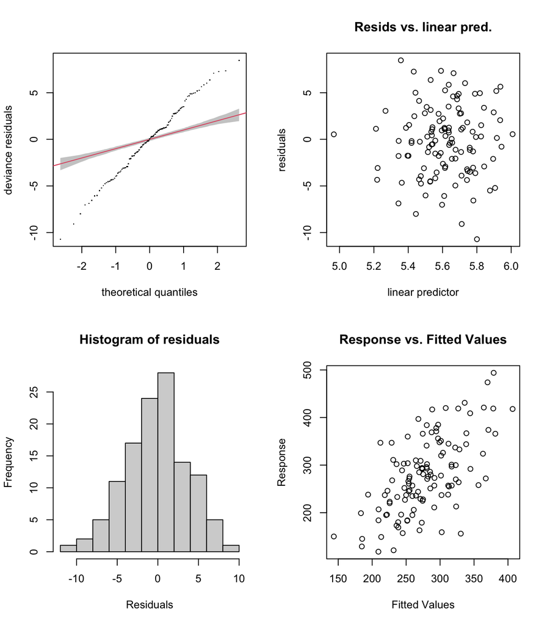

```
##
## Method: REML   Optimizer: outer newton
## full convergence after 8 iterations.
## Gradient range [-4.342831e-07,2.844613e-06]
## (score 1402.052 & scale 1).
## Hessian positive definite, eigenvalue range [1.705908,3.365045].
## Model rank =  46 / 46
##
## Basis dimension (k) checking results. Low p-value (k-index<1) may
## indicate that k is too low, especially if edf is close to k'.
##
##                        k'  edf k-index p-value
## s(logitNatDensBasMp) 9.00 8.53    1.13    0.93
## s(log10Dis2Cost)     9.00 8.60    0.92    0.14
## s(HII)               9.00 7.29    1.10    0.83
## s(log10Slope30mAgg)  9.00 8.63    1.10    0.83
## s(PrecSea)           9.00 8.60    1.03    0.60
```

```r
#Use the function `gam.check()` to assess the model
par(mfcol= c(2,2))
gam.check(DK.Biodiv.gam, # a fitted gam
          type = "deviance", # type of residuals
          rep = 500)
```

**Question:** Based on the figure you just created and the *Printout* of running the function `gam.check()` :

1. Are the residuals random? [look at the table of Basis dimension (k) printed by the function `gam.check()`]

Yes!! the table shows that model residuals are random as the p-values are large..

2. Are the residuals normally distributed? The histogram looks normal but the qqplot shows that this is not the case
3. Is there Homogeneity of variances? Yes there is no trend in the residuals
4. Is this a good model? Yes, The relation is fairly linear

## 5) Check for concurvity

**Your task:**

- Use the function `concurvity()` of the `mgcv` package to test for **concurvity** of the `DK.Biodiv.gam` model.
  1. Set the `full` argument to `TRUE` to establish the pairwise concurvity for each smooth for all variables.
  2. Set the `full` argument to `FALSE` to establish the overall concurvity for all pairwise combinations of variables.

Remember that **concurvity** is the extra analysis in **GAMs** that complements the collinearity assessments. Here you are testing if one predictors is a smooth curve of another.

Also if the values is over 0.8, there is a problem.

```r
# test for the overall concurvity
concurvity(DK.Biodiv.gam,
           full = TRUE)
```

```
##                  para s(logitNatDensBasMp) s(log10Dis2Cost)    s(HII)
## worst    5.181496e-20            0.5195662        0.6898235 0.7184608
## observed 5.181496e-20            0.2913275        0.4899727 0.3711724
## estimate 5.181496e-20            0.3968665        0.4300814 0.4164770
##          s(log10Slope30mAgg) s(PrecSea)
## worst              0.7118657  0.6799289
## observed           0.3761184  0.4414915
## estimate           0.4963998  0.4830098
```

```r
# test for the pairwise concurvity
concurvity(DK.Biodiv.gam,
           full = FALSE)
```

```
## $worst
##                              para s(logitNatDensBasMp) s(log10Dis2Cost)
## para                 1.000000e+00         1.234176e-26     2.016844e-22
## s(logitNatDensBasMp) 1.280955e-26         1.000000e+00     2.655114e-01
## s(log10Dis2Cost)     2.017030e-22         2.655114e-01     1.000000e+00
## s(HII)               8.520696e-26         2.545364e-01     3.118196e-01
## s(log10Slope30mAgg)  7.918114e-27         2.318819e-01     2.106143e-01
## s(PrecSea)           3.017777e-20         2.127647e-01     2.984533e-01
##                            s(HII) s(log10Slope30mAgg)   s(PrecSea)
## para                 8.423254e-26        7.839345e-27 3.017855e-20
## s(logitNatDensBasMp) 2.545364e-01        2.318819e-01 2.127647e-01
## s(log10Dis2Cost)     3.118196e-01        2.106143e-01 2.984533e-01
## s(HII)               1.000000e+00        3.198413e-01 3.429427e-01
## s(log10Slope30mAgg)  3.198413e-01        1.000000e+00 3.427114e-01
## s(PrecSea)           3.429427e-01        3.427114e-01 1.000000e+00
##
## $observed
##                              para s(logitNatDensBasMp) s(log10Dis2Cost)
## para                 1.000000e+00         2.501312e-31     2.232804e-23
## s(logitNatDensBasMp) 1.280955e-26         1.000000e+00     1.114864e-01
## s(log10Dis2Cost)     2.017030e-22         6.690885e-02     1.000000e+00
## s(HII)               8.520696e-26         4.521701e-02     1.103189e-01
## s(log10Slope30mAgg)  7.918114e-27         6.508132e-02     1.628368e-01
## s(PrecSea)           3.017777e-20         1.218350e-01     1.754151e-01
##                            s(HII) s(log10Slope30mAgg)   s(PrecSea)
## para                 1.954194e-27        1.581648e-27 9.759427e-23
## s(logitNatDensBasMp) 9.164486e-02        5.941709e-02 8.591397e-02
## s(log10Dis2Cost)     1.005766e-01        1.376347e-01 8.865026e-02
## s(HII)               1.000000e+00        9.589703e-02 2.014459e-01
## s(log10Slope30mAgg)  7.584469e-02        1.000000e+00 7.839211e-02
## s(PrecSea)           7.691971e-02        1.342983e-01 1.000000e+00
##
## $estimate
##                              para s(logitNatDensBasMp) s(log10Dis2Cost)
## para                 1.000000e+00         5.524283e-29     1.461609e-24
## s(logitNatDensBasMp) 1.280955e-26         1.000000e+00     8.773002e-02
## s(log10Dis2Cost)     2.017030e-22         1.026686e-01     1.000000e+00
## s(HII)               8.520696e-26         1.292345e-01     9.637236e-02
## s(log10Slope30mAgg)  7.918114e-27         5.502561e-02     1.231600e-01
## s(PrecSea)           3.017777e-20         1.165844e-01     1.707631e-01
##                            s(HII) s(log10Slope30mAgg)   s(PrecSea)
## para                 2.324805e-28        4.330465e-29 4.296040e-23
## s(logitNatDensBasMp) 1.318982e-01        1.042429e-01 1.155427e-01
## s(log10Dis2Cost)     1.420676e-01        1.111706e-01 7.430253e-02
## s(HII)               1.000000e+00        1.365841e-01 1.136870e-01
## s(log10Slope30mAgg)  1.116683e-01        1.000000e+00 2.375658e-01
## s(PrecSea)           7.600025e-02        2.049991e-01 1.000000e+00
```

**Question:** is there a **concurvity** problem with your predictors?

NO!; both the pairwise and overall concurvity assessments show values below the 0.8 threshold.

## 6) Adding interacting terms

**Your task:**

- Use the `gam()` function to evaluate a poisson regression with all the **CONTINOUS** predictors,
- Now add `latitude` and `longitude`as an interacting term as a Bivariate thin plate spline.
- Remember to include the adequate error `family` for the type of data in `S.AllGrp`.

```r
# Build a gam to predict S.AllGrp based on a linear combination of logitNatDensBasMp, log10Dis2Cost, HII, log10Slope30mAgg, PrecSea as smoothed terms - remember to adjust the maximum smooth term for each predictor variable.
# Save the Model as an object named DK.Biodiv.gam.2
DK.Biodiv.gam.2 <- gam(S.AllGrp ~ s(logitNatDensBasMp,k=10) + s(log10Dis2Cost,k=10) + s(HII,k=10) + s(log10Slope30mAgg,k=10) + s(PrecSea,k=10) + s(decimalLongitude,decimalLatitude, bs="tp"), #  the Equations defining the response and additive combination of predictors
                  data = DK.Biodiv, # specify the Object where the data is in
                  family = "poisson", # Argument defining the adequate error `family` given the type of the response variable (quasi)binomial for presence/absence and proportion data, and (quasi)Poisson for counts.
                  method ="REML")
# Print the summary of the gam model
summary(DK.Biodiv.gam.2)
```

```
##
## Family: poisson
## Link function: log
##
## Formula:
## S.AllGrp ~ s(logitNatDensBasMp, k = 10) + s(log10Dis2Cost, k = 10) +
##     s(HII, k = 10) + s(log10Slope30mAgg, k = 10) + s(PrecSea,
##     k = 10) + s(decimalLongitude, decimalLatitude, bs = "tp")
##
## Parametric coefficients:
##             Estimate Std. Error z value Pr(>|z|)
## (Intercept) 5.603991   0.005607   999.5   <2e-16 ***
## ---
## Signif. codes:  0 '***' 0.001 '**' 0.01 '*' 0.05 '.' 0.1 ' ' 1
##
## Approximate significance of smooth terms:
##                                        edf Ref.df Chi.sq p-value
## s(logitNatDensBasMp)                 8.669  8.952  325.2  <2e-16 ***
## s(log10Dis2Cost)                     8.728  8.944  165.7  <2e-16 ***
## s(HII)                               8.456  8.870  132.1  <2e-16 ***
## s(log10Slope30mAgg)                  8.607  8.937  375.2  <2e-16 ***
## s(PrecSea)                           7.984  8.605  103.1  <2e-16 ***
## s(decimalLongitude,decimalLatitude) 27.468 28.549  600.8  <2e-16 ***
## ---
## Signif. codes:  0 '***' 0.001 '**' 0.01 '*' 0.05 '.' 0.1 ' ' 1
##
## R-sq.(adj) =  0.206   Deviance explained = 65.3%
## -REML = 1141.8  Scale est. = 1         n = 120
```

**Question:** How much did your model improved by adding the spatial context?

There was an improvement of ~26% in explained deviance. now the model explains ~65% of the Deviance.

## 7) Check you expanded GAM model

**Your task:** * Use the function `gam.check()` to assess `DK.Biodiv.gam.2`: 1) do you have the right number of basis functions for each smoother. 2) Distribution of the residuals, 3) Homogeneity of variances. 4) Goodness of fit of your model.

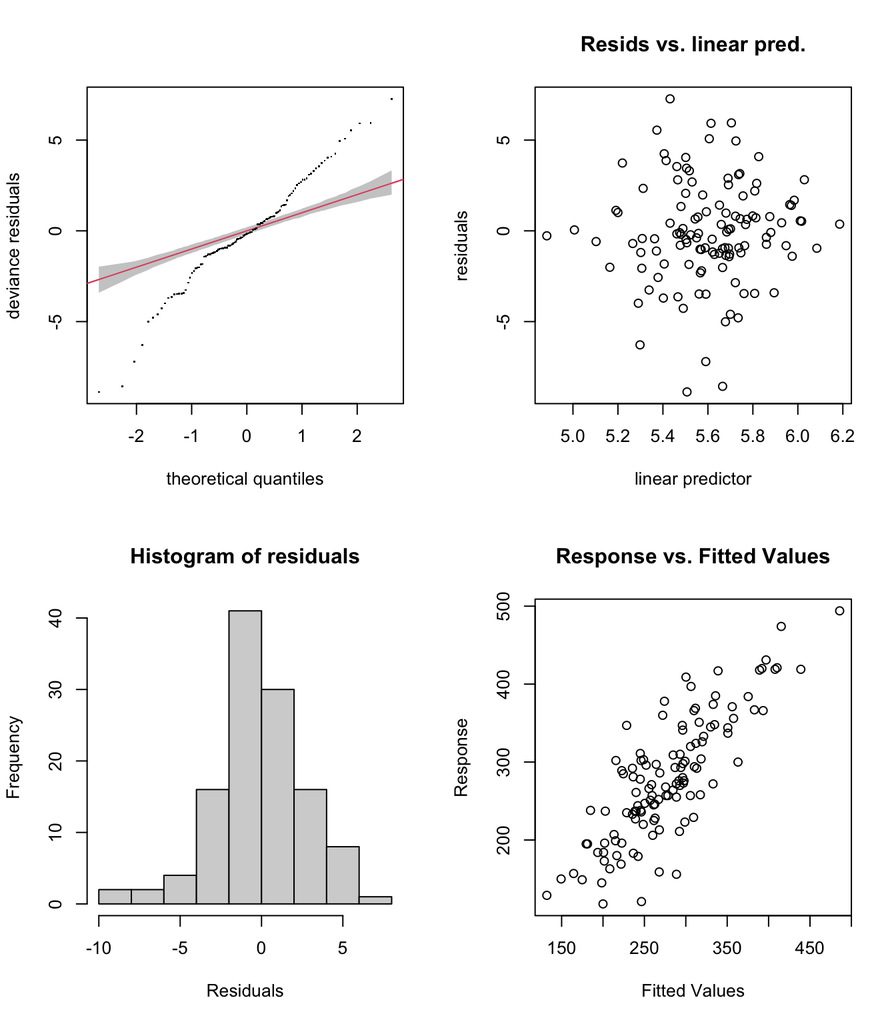

```
##
## Method: REML   Optimizer: outer newton
## full convergence after 10 iterations.
## Gradient range [-7.505493e-07,1.377602e-06]
## (score 1141.817 & scale 1).
## Hessian positive definite, eigenvalue range [2.426472,10.05456].
## Model rank =  75 / 75
##
## Basis dimension (k) checking results. Low p-value (k-index<1) may
## indicate that k is too low, especially if edf is close to k'.
##
##                                        k'   edf k-index p-value
## s(logitNatDensBasMp)                 9.00  8.67    0.96    0.28
## s(log10Dis2Cost)                     9.00  8.73    0.99    0.43
## s(HII)                               9.00  8.46    1.08    0.81
## s(log10Slope30mAgg)                  9.00  8.61    1.19    0.97
## s(PrecSea)                           9.00  7.98    1.21    0.99
## s(decimalLongitude,decimalLatitude) 29.00 27.47    1.28    1.00
```

```r
#Use the function `gam.check()` to assess the model
par(mfcol= c(2,2))
gam.check(DK.Biodiv.gam.2, # a fitted gam
          type = "deviance", # type of residuals
          rep = 500)
```

**Question:** Based on the figure you just created and the *Printout* of running the function `gam.check()` :

1. Are the residuals random? [look at the table of Basis dimension (k) printed by the function `gam.check()`]

Yes!! the table shows that model residuals are random as the p-values are large.

2. Are the residuals normally distributed? The histogram looks more normal but the qqplot still shows that this is not the case
3. Is there Homogeneity of variances? Yes there is no trend in the residuals
4. Is this a good model? Yes, The relation is fairly linear

## 8) Simplify your model

**Your task:** * Read the help file fo the function `gam()` from the `mgcv` package and try to understand what does the `select` argument does.

- Now update you `DK.Biodiv.gam.2` gam model to include the `select` argument. for this use the function `update()`.

```r
# Now update you `DK.Biodiv.gam.2` gam model to include the `select` argument.
# Save the updated model as DK.Biodiv.gam.3

DK.Biodiv.gam.3 <- update(DK.Biodiv.gam.2, # the model to update
                          select = TRUE ) #add an extra penalty to each term so that it can be penalized to zero

# Print the summary of the DK.Biodiv.gam.3 object
summary(DK.Biodiv.gam.3)
```

```
##
## Family: poisson
## Link function: log
##
## Formula:
## S.AllGrp ~ s(logitNatDensBasMp, k = 10) + s(log10Dis2Cost, k = 10) +
##     s(HII, k = 10) + s(log10Slope30mAgg, k = 10) + s(PrecSea,
##     k = 10) + s(decimalLongitude, decimalLatitude, bs = "tp")
##
## Parametric coefficients:
##             Estimate Std. Error z value Pr(>|z|)
## (Intercept) 5.604336   0.005604    1000   <2e-16 ***
## ---
## Signif. codes:  0 '***' 0.001 '**' 0.01 '*' 0.05 '.' 0.1 ' ' 1
##
## Approximate significance of smooth terms:
##                                        edf Ref.df Chi.sq p-value
## s(logitNatDensBasMp)                 8.610      9  372.6  <2e-16 ***
## s(log10Dis2Cost)                     7.813      9  210.6  <2e-16 ***
## s(HII)                               8.473      9  140.6  <2e-16 ***
## s(log10Slope30mAgg)                  8.413      9  430.4  <2e-16 ***
## s(PrecSea)                           7.800      9  111.5  <2e-16 ***
## s(decimalLongitude,decimalLatitude) 25.852     29  652.6  <2e-16 ***
## ---
## Signif. codes:  0 '***' 0.001 '**' 0.01 '*' 0.05 '.' 0.1 ' ' 1
##
## R-sq.(adj) =  0.245   Deviance explained = 64.9%
## -REML =   1146  Scale est. = 1         n = 120
```

**Question:** What is different between `DK.Biodiv.gam.2` and `DK.Biodiv.gam.3`?

## 9) Which variables to keep

**Your task:**

- Evaluate which soothers you need to keep in you model by comparing the deviance of your fill model `DK.Biodiv.gam.3` to models that remove only one of the smoothing functions.

```r
# Update the full model to a simpler models - with one variable removed -  use the function update() to remove variables from the full model.
UpdateMod <- lapply(strsplit(as.character(formula(DK.Biodiv.gam.3))[[3]]," [+] ")[[1]],
                    function(x){
                      update(DK.Biodiv.gam.3, # the model to update
                           formula(paste('. ~ . - ',x)))# Updated formula
                    })
# Evaluate the change in deviance of simpler models - with one variable removed - use the function anova() to contrast the full gam to those with one less variable now stored in UpdateMod
DevChng <- sapply(UpdateMod,
                  function(x){
                    out <- anova(x, # Reduced model
                                 DK.Biodiv.gam.3, # Full Model
                                 test="Chisq" # type of test
                                 )
                    c(Deviance = out$Deviance[2],
                      Pval = out[2,'Pr(>Chi)'])
                    })
# Contrast the AIC of the full and reduced models stored in UpdateMod
AIC.Dif <- sapply(UpdateMod,
                  function(x){
                    AIC(x, # Reduced model
                        DK.Biodiv.gam.3)$AIC # Full Model)
                  })
# create  data.frame to summarize the deviance tests
 data.frame (VarRem = strsplit(as.character(formula(DK.Biodiv.gam.3))[[3]]," [+] ")[[1]],
             t(round(DevChng, 3)),
             AIC.Reduced = AIC.Dif[1,],
             AIC.full = AIC.Dif[2,])
```

```
##                                            VarRem Deviance Pval AIC.Reduced
## 1                    s(logitNatDensBasMp, k = 10)  353.153    0    2323.515
## 2                        s(log10Dis2Cost, k = 10)  185.530    0    2156.793
## 3                                  s(HII, k = 10)  149.751    0    2123.200
## 4                     s(log10Slope30mAgg, k = 10)  412.441    0    2381.294
## 5                              s(PrecSea, k = 10)  108.976    0    2085.692
## 6 s(decimalLongitude, decimalLatitude, bs = "tp")  717.403    0    2648.999
##   AIC.full
## 1 1987.348
## 2 1987.348
## 3 1987.348
## 4 1987.348
## 5 1987.348
## 6 1987.348
```

**Question:** based on these test, do you need to remove any smoother?

NO, the full model is significantly different than a simpler model, and has a lower AIC

## 10) Plot the Best model

**Your task:**

- Plot the best model selected in the previous step using the function `plot()`.

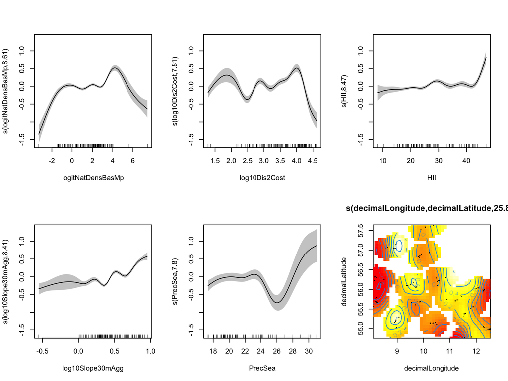

```r
# Plot the best model
plot(DK.Biodiv.gam.3,
     pages = 1, # the number of pages over which to spread the output
     scheme = 2, # produces a heat-map, with overlaid contours and
     shade = TRUE) # produce shaded regions as confidence bands
```

**Question:** Make an interpretation of the plotted output.

The lines indicate how the response variable (Species richness) changes as a smoothed function of each predictor.

## 11) Make predictions using your GAM - Data preparation

**Your task:**

- Load the rasters with the spatial information for:

  **1) Density of natural land cover types** - *NatDensBasMp.tif* **2) Distance to the coast** - *Dis2Cost.tif* **3) Human Influence Index** - *HII.tif* **4) Slope** - *Slope30mAgg.tif* **5) Seasonality of precipitation** - *PrecSea.tif*

```r
# Load the NatDensBasMp raster
NatDensBasMpRst <- raster("Data/NatDensBasMp.tif")
# Load the Dis2Cost raster
Dis2CostRst <- raster("Data/Dis2Cost.tif")
# Load the HII raster
HIIRst <- raster("Data/HII.tif")
# Load the Slope30mAgg raster
Slope30mAggRst <- raster("Data/Slope30mAgg.tif")
# Load the PrecSea raster
PrecSeaRst <- raster("Data/PrecSea.tif")
```

**Question:** Can you stack these rasters?

No, because come of these are in different projections.

**Your task:**

- Stack the loaded rasters with the spatial information into a object named `Pred.Rast`.

Here remember that some of these are not in the required projection *ETRS89 / UTM zone 32N*. use the function `projectRaster()` to re-project those rasters that need to be re-projected.

Also, make sure that all rasters have the same extend and number of cells. Those rasters that are initialised can be corrected using the function `resample()`.

```r
# Re project the rasters that need to be place in *ETRS89 / UTM zone 32N*
HIIRst <- projectRaster(from = HIIRst,
                        to = NatDensBasMpRst)
Slope30mAggRst <- projectRaster(from = Slope30mAggRst,
                        to = NatDensBasMpRst)

# Stack the corrected rasters
Pred.Rast <- stack(NatDensBasMpRst, # Nature Density Raster
                   Dis2CostRst, # Distance to coast Raster
                   HIIRst, # HII to coast
                   Slope30mAggRst, # Slope to coast
                   PrecSeaRst # Precipitation seasonality to coast
                   )
# call the Pred.Rast object
Pred.Rast
```

```
## class      : RasterStack
## dimensions : 369, 460, 169740, 5  (nrow, ncol, ncell, nlayers)
## resolution : 1000, 1000  (x, y)
## extent     : 433390, 893390, 6038850, 6407850  (xmin, xmax, ymin, ymax)
## crs        : +proj=utm +zone=32 +ellps=GRS80 +units=m +no_defs
## names      :  NatDensBasMp,      Dis2Cost,           HII,   Slope30mAgg,       PrecSea
## min values :  0.000000e+00, -8.448879e+01,  4.000000e+00,  4.969617e-17,  1.600000e+01
## max values :       1.00000,   48891.18825,      64.00000,      26.91266,      31.00000
```

**Question:** Are you missing any of the variables used in your model?

Yes, Latitude and longitude

**Your task:**

- Create the rasters you are missing using the information in `Pred.Rast`.
- Append these rasters to `Pred.Rast`.

```r
# Create the missing variable(s).
# Create a empt raster with the same attributes as Pred.Rast using the function raster
LatRast <- raster(Pred.Rast)
## re-project the created raster
LatRast <- projectRaster(from = LatRast, # Transformation
                             crs = CRS("+proj=longlat +datum=WGS84 +no_defs") # CRS object
                        )
## Add the values to the created raster
LatRast[] <- coordinates(LatRast)[,"y"]
## re-project created raster
LatRast <- projectRaster(from = LatRast,
                         to = Pred.Rast)
## Append new rasters to Pred.Rast
Pred.Rast <- stack(Pred.Rast,
                    LatRast) # new Raster 1

# Create a empt raster with the same attributes as Pred.Rast using the function raster
LongRast <- raster(Pred.Rast)
## re-project the created raster
LongRast <- projectRaster(from = LongRast, # Transformation
                          crs = CRS("+proj=longlat +datum=WGS84 +no_defs") # CRS object
                        )
## Add the values to the created raster
LongRast[] <- coordinates(LongRast)[,"y"]

## re-project created raster
LongRast <- projectRaster(from = LongRast,
                         to = Pred.Rast)

## Append new rasters to Pred.Rast
Pred.Rast <- stack(Pred.Rast,
                    LongRast) # new Raster 1

# call the Pred.Rast object
Pred.Rast
```

```
## class      : RasterStack
## dimensions : 369, 460, 169740, 7  (nrow, ncol, ncell, nlayers)
## resolution : 1000, 1000  (x, y)
## extent     : 433390, 893390, 6038850, 6407850  (xmin, xmax, ymin, ymax)
## crs        : +proj=utm +zone=32 +ellps=GRS80 +units=m +no_defs
## names      :  NatDensBasMp,      Dis2Cost,           HII,   Slope30mAgg,       PrecSea,       layer.1,       layer.2
## min values :  0.000000e+00, -8.448879e+01,  4.000000e+00,  4.969617e-17,  1.600000e+01,  5.435008e+01,  5.435008e+01
## max values :       1.00000,   48891.18825,      64.00000,      26.91266,      31.00000,      57.80814,      57.80814
```

## 12) Make predictions using your GAM - Use your model on a `RasterStack`

**Question:** Are the rasters you have compiled into a `RasterStack` in the same units as the predictions in your model?

No.

1. `NatDensBasMpRst` needs to be transformed into `logitNatDensBasMpRst`
2. `Dis2CostRst` needs to be transformed into `log10Dis2CostRst`
3. `Slope30mAggRst` needs to be transformed into `log10Slope30mAgg`

**Your task:**

- Transform those rasters that need transformation into the units of the predictors used in your model.
- Add the transformed rasters to `Pred.Rast`.

```r
# Transform those rasters that need transformation
## Transform NatDensBasMpRst
logitNatDensBasMpRst <- calc(NatDensBasMpRst,
                             function(x){
                               ifelse(!is.na(x),
                                      car::logit(x),
                                      NA)
                             })
## Add logitNatDensBasMpRst to Pred.Rast
Pred.Rast <- stack(Pred.Rast,
                   logitNatDensBasMpRst)

## Transform Dis2CostRst
log10Dis2CostRst <- log10(Dis2CostRst)
## Add log10Dis2CostRst to Pred.Rast
Pred.Rast <- stack(Pred.Rast,
                   log10Dis2CostRst)

## Transform Slope30mAggRst
log10Slope30mAggRst <- log10(Slope30mAggRst)
## Add log10Slope30mAggRst to Pred.Rast
Pred.Rast <- stack(Pred.Rast,
                   log10Slope30mAggRst = log10Slope30mAggRst)

# call the Pred.Rast object
Pred.Rast
```

```
## class      : RasterStack
## dimensions : 369, 460, 169740, 10  (nrow, ncol, ncell, nlayers)
## resolution : 1000, 1000  (x, y)
## extent     : 433390, 893390, 6038850, 6407850  (xmin, xmax, ymin, ymax)
## crs        : +proj=utm +zone=32 +ellps=GRS80 +units=m +no_defs
## names      :  NatDensBasMp,      Dis2Cost,           HII,   Slope30mAgg,       PrecSea,     layer.1.1,     layer.2.1,     layer.1.2,     layer.2.2,         layer
## min values :  0.000000e+00, -8.448879e+01,  4.000000e+00,  4.969617e-17,  1.600000e+01,  5.435008e+01,  5.435008e+01, -3.663562e+00,  7.259132e-01, -1.630368e+01
## max values :      1.000000,  48891.188254,     64.000000,     26.912659,     31.000000,     57.808139,     57.808139,      3.663562,      4.689231,      1.429957
```

**Your task:**

- Use the function `predict()` to implement your gam model (`DK.Biodiv.gam.3`) using the data in `Pred.Rast` for this:
  1. Make sure the names of the layers in `Pred.Rast` match the names of the predictors in `DK.Biodiv.gam.3`. If they do not match use the function `names()` to change these.
  2. Read the help function of the function `predict()` to see how implement it with raster data (type `?predict` to check this). **Remember you made a *poisson* regression, so you need to back transform the predictions**.
  3. Save the output as a object named `DK.BiodivMap`

```r
# Check names
names(Pred.Rast)
```

```
##  [1] "NatDensBasMp" "Dis2Cost"     "HII"          "Slope30mAgg"  "PrecSea"
##  [6] "layer.1.1"    "layer.2.1"    "layer.1.2"    "layer.2.2"    "layer"
```

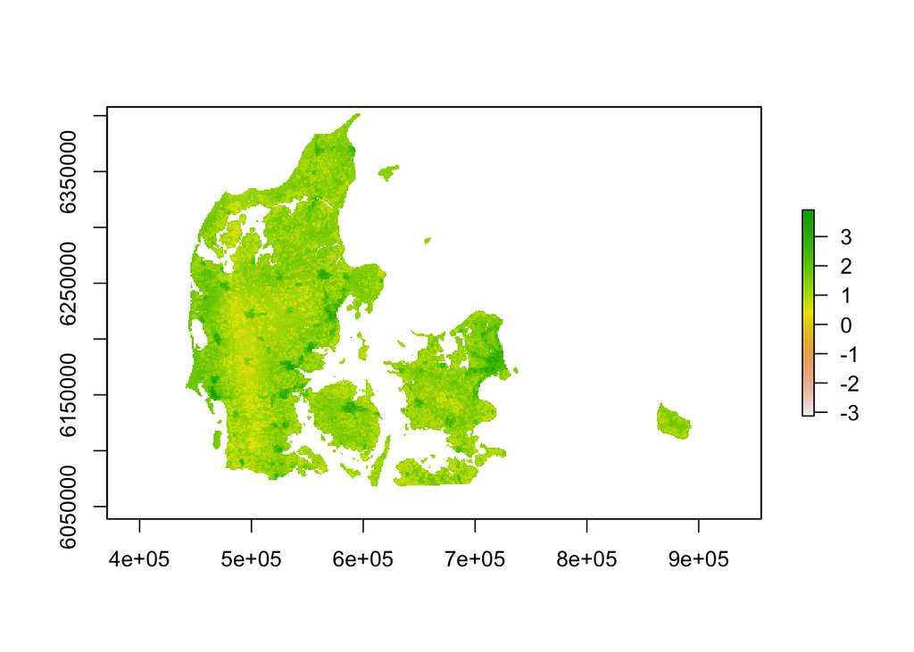

```r
# Change names
names(Pred.Rast) <- c("NatDensBasMp",
                      "Dis2Cost",
                      "HII",
                      "Slope30mAgg",
                      "PrecSea",
                      "decimalLatitude",
                      "decimalLongitude",
                      "logitNatDensBasMp",
                      "log10Dis2Cost",
                      "log10Slope30mAgg")
# Predict model
DK.BiodivMap <- predict(object = Pred.Rast,
                        model = DK.Biodiv.gam.3,
                        type = "response")
# Plot your predictions
plot(log10(abs(DK.BiodivMap)))
```